# Task 1

Explore the **file school_and_country_table.csv**

Note: Required "World Unversity Ranking" Datasets from Kaggle have been downloaded and saved into local system

```python
# Import Python Libraries

import numpy as np
import pandas as pd
import matplotlib.pyplot as plt
import seaborn as sns
import os
%matplotlib inline
```

# Exploratory Data Analysis for "school_and_country_table.csv"

```python
# Reading and bringing in data from "school_and_country_table.csv" into a dataframe using pandas read_csv
df = pd.read_csv("school_and_country_table.csv")
```

```python
# Checking total number of rows and columns in the dataset
df.shape
```

```
(818, 2)
```

```python
# Looking at data sample by fetching first 10 rows
df.head(10)
```

|  | school_name | country |
| --- | --- | --- |
| 0 | Harvard University | United States of America |
| 1 | California Institute of Technology | United States of America |
| 2 | Massachusetts Institute of Technology | United States of America |
| 3 | Stanford University | United States of America |
| 4 | Princeton University | United States of America |
| 5 | University of Cambridge | United Kingdom |
| 6 | University of Oxford | United Kingdom |
| 7 | University of California, Berkeley | United States of America |
| 8 | Imperial College London | United Kingdom |
| 9 | Yale University | United States of America |

```python
# Checking basic statistics about data in the dataset
df.describe()
```

|  | school_name | country |
| --- | --- | --- |
| count | 818 | 818 |
| unique | 818 | 70 |
| top | Hong Kong University of Science and Technology | United States of America |
| freq | 1 | 161 |

```python
#Gathering more information on the data in the dataset so as to see data types of attributes
#It also helps to check if the attributes have any missing values
df.info()
```

```
<class 'pandas.core.frame.DataFrame'>
RangeIndex: 818 entries, 0 to 817
Data columns (total 2 columns):
school_name    818 non-null object
country        818 non-null object
dtypes: object(2)
memory usage: 12.9+ KB
```

From the above information retreived about school and country data,we can clearly see that there are no missing values in any of the attributes and both of them are having approriate data type in accordance to the data value they contain. Therefore,there is no need to perform 'Data Cleansing or Data Preparation' step.

We can further proceed to doing our data analysis.

## Frequency Distribution Analysis - No. of universities in each country

```python
df['country'].value_counts()
```

```
United States of America    161
United Kingdom               78
Japan                        41
Germany                      39
China                        38
Italy                        34
Australia                    31
France                       28
Canada                       25
Spain                        25
Taiwan                       24
South Korea                  24
India                        17
Brazil                       17
Russian Federation           13
Netherlands                  13
Turkey                       11
Sweden                       11
Switzerland                  10
Czech Republic                9
Finland                       9
Republic of Ireland           9
Iran                          8
Thailand                      7
Greece                        7
New Zealand                   7
Portugal                      7
Austria                       7
Belgium                       7
Poland                        7
                           ...
Egypt                         3
Mexico                        2
Slovakia                      2
Jordan                        2
Colombia                      2
Slovenia                      2
Pakistan                      2
Ukraine                       2
Singapore                     2
Estonia                       2
United Arab Emirates          2
Indonesia                     1
Lithuania                     1
Ghana                         1
Morocco                       1
Uganda                        1
Oman                          1
Belarus                       1
Qatar                         1
Nigeria                       1
Lebanon                       1
Iceland                       1
Latvia                        1
Serbia                        1
Luxembourg                    1
Macau                         1
Bangladesh                    1
Kenya                         1
Cyprus                        1
Argentina                     1
Name: country, Length: 70, dtype: int64
```

#### Generic setting for all upcoming visualizations

```python
# Settings to switch -off the grid lines and making background white for all visualizations using seaborn
sns.set_style("white")
```

### Vizualization for Frequency Distribution Analysis (Country Vs No. of Universities)

```
Text(0,0.5,'Number of Universities')
```

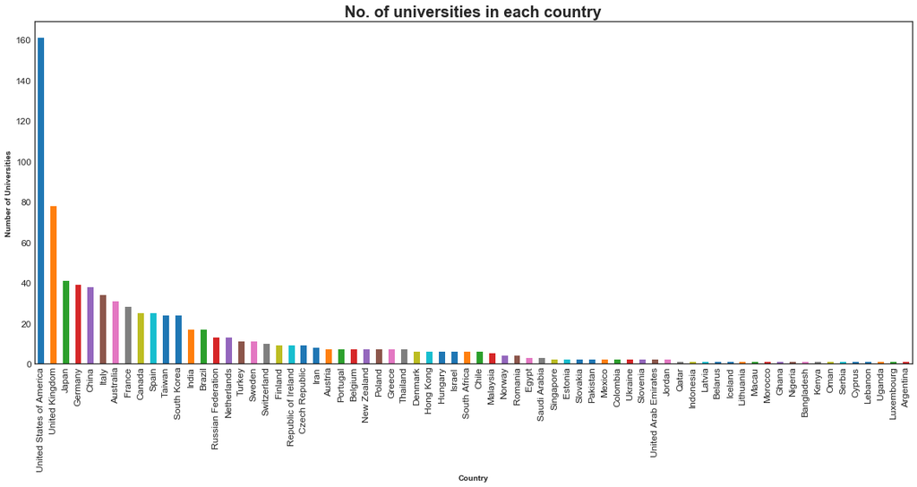

```python
# Using Matplotlib to visualize frequency distribution by means of a 'bar' plot
ax=df['country'].value_counts().plot('bar',figsize=(20,8),fontsize=12)
ax.set_alpha(0.8)
ax.set_title('No. of universities in each country',fontsize=20,fontweight='bold')
ax.set_xlabel('Country',fontweight='bold')
ax.set_ylabel('Number of Universities',fontweight='bold')
```

## Top 10 Countries with most no. of universities in the world

```
Text(0,0.5,'Number of universities')
```

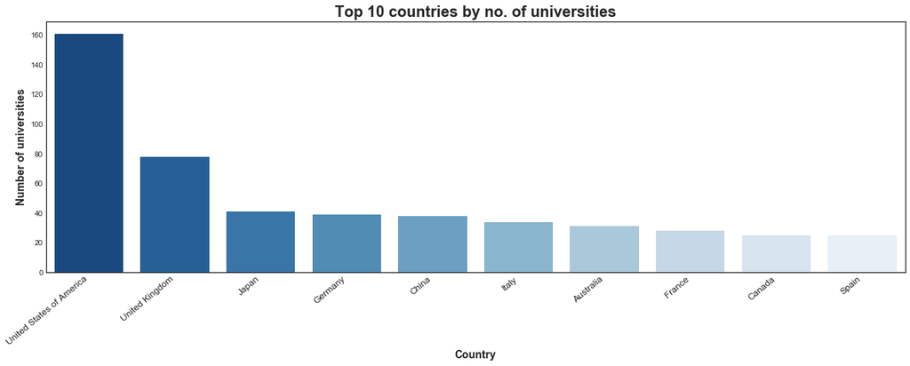

```python
# Using seaborn library of Python for visualizing by means of a countplot
plt.figure(figsize=(20,6))
ax=sns.countplot(x="country",data=df,palette="Blues_r",order=df.country.value_counts().iloc[:10].index)
ax.set_xticklabels(ax.get_xticklabels(), rotation=40, ha="right",fontsize=12)
plt.title('Top 10 countries by no. of universities',fontsize=20,fontweight='bold')
plt.xlabel('Country',fontsize=14,fontweight='bold')
plt.ylabel('Number of universities',fontsize=14,fontweight='bold')
```

## Bottom 10 countries with least no. of universities in the world

```
Text(0,0.5,'Number of universities')
```

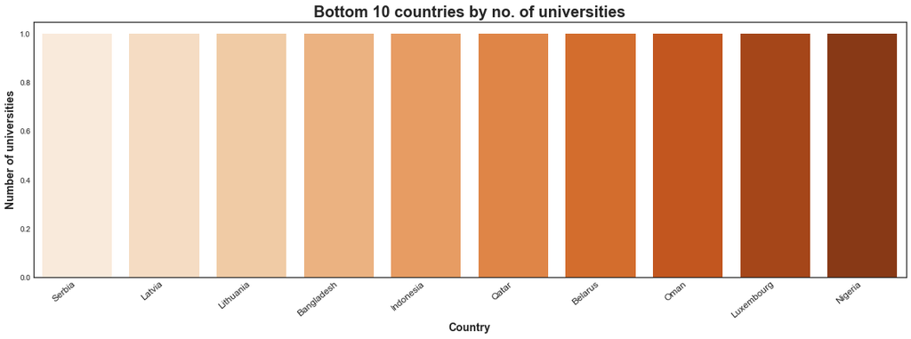

```python
#Again using seaborn for visualization
plt.figure(figsize=(20,6))
ax=sns.countplot(x="country",data=df,palette="Oranges",order=df.country.value_counts().iloc[-10:].index)
ax.set_xticklabels(ax.get_xticklabels(), rotation=40, ha="right",fontsize=12)
plt.title('Bottom 10 countries by no. of universities',fontsize=20,fontweight='bold')
plt.xlabel('Country',fontsize=14,fontweight='bold')
plt.ylabel('Number of universities',fontsize=14,fontweight='bold')
```

## Task 2

## Creating a function named "answer_two"

*function "answer_two()" returns a list of countries with only 1 university alphabetically sorted by ascending*

```python
def answer_two():
    df = pd.read_csv("school_and_country_table.csv")
    x=df['country'].value_counts()[df['country'].value_counts()==1]
    countries_with_one_university = x.index.tolist()
    countries_with_one_university.sort()
    return countries_with_one_university;
answer_two()
```

```
['Argentina',
 'Bangladesh',
 'Belarus',
 'Cyprus',
 'Ghana',
 'Iceland',
 'Indonesia',
 'Kenya',
 'Latvia',
 'Lebanon',
 'Lithuania',
 'Luxembourg',
 'Macau',
 'Morocco',
 'Nigeria',
 'Oman',
 'Qatar',
 'Serbia',
 'Uganda']
```

**Completion of Task 2**

**Here starts Task 3**

Explore "timesData.csv"

*which one of the universities from the list obtained with answer_two() is most friendly to foreigners? (consider international_students) Function answer_three should return one string value*

# Exploratory Data Analysis for Times Higher Education World University Ranking

```python
# Reading and bringing in data from "timesData.csv" into a dataframe using pandas read_csv
df = pd.read_csv("timesData.csv")
# Checking total number of rows and columns in the dataset
df.shape
```

```
(2603, 14)
```

```python
# Looking at data sample by fetching first 10 rows
df.head()
```

|  | world_rank | university_name | country | teaching | international | research | citations | income | total_score | num_students | student_staff_ratio | international_students | female_male_ratio | year |
| --- | --- | --- | --- | --- | --- | --- | --- | --- | --- | --- | --- | --- | --- | --- |
| 0 | 1 | Harvard University | United States of America | 99.7 | 72.4 | 98.7 | 98.8 | 34.5 | 96.1 | 20,152 | 8.9 | 25% | NaN | 2011 |
| 1 | 2 | California Institute of Technology | United States of America | 97.7 | 54.6 | 98.0 | 99.9 | 83.7 | 96.0 | 2,243 | 6.9 | 27% | 33 : 67 | 2011 |
| 2 | 3 | Massachusetts Institute of Technology | United States of America | 97.8 | 82.3 | 91.4 | 99.9 | 87.5 | 95.6 | 11,074 | 9.0 | 33% | 37 : 63 | 2011 |
| 3 | 4 | Stanford University | United States of America | 98.3 | 29.5 | 98.1 | 99.2 | 64.3 | 94.3 | 15,596 | 7.8 | 22% | 42 : 58 | 2011 |
| 4 | 5 | Princeton University | United States of America | 90.9 | 70.3 | 95.4 | 99.9 | - | 94.2 | 7,929 | 8.4 | 27% | 45 : 55 | 2011 |

```python
# Checking basic statistics about data in the dataset
df.describe()
```

|  | teaching | research | citations | student_staff_ratio | year |
| --- | --- | --- | --- | --- | --- |
| count | 2603.000000 | 2603.000000 | 2603.000000 | 2544.000000 | 2603.000000 |
| mean | 37.801498 | 35.910257 | 60.921629 | 18.445283 | 2014.075682 |
| std | 17.604218 | 21.254805 | 23.073219 | 11.458698 | 1.685733 |
| min | 9.900000 | 2.900000 | 1.200000 | 0.600000 | 2011.000000 |
| 25% | 24.700000 | 19.600000 | 45.500000 | 11.975000 | 2013.000000 |
| 50% | 33.900000 | 30.500000 | 62.500000 | 16.100000 | 2014.000000 |
| 75% | 46.400000 | 47.250000 | 79.050000 | 21.500000 | 2016.000000 |
| max | 99.700000 | 99.400000 | 100.000000 | 162.600000 | 2016.000000 |

No statistical insights are shown by describe() function for the following features:

- 'world_rank'
- 'international'
- 'income'
- 'total_score'
- 'num_students'
- 'international_students'
- 'female_male_ratio'

This is because of their non numeric data types and further need to transform data in these fields into suitable format for data analysis.

```python
# Gathering more information on the data in the dataset so as to see data types of attributes
# It also helps to check if the attributes have any missing values
df.info()
```

```
<class 'pandas.core.frame.DataFrame'>
RangeIndex: 2603 entries, 0 to 2602
Data columns (total 14 columns):
world_rank                2603 non-null object
university_name           2603 non-null object
country                   2603 non-null object
teaching                  2603 non-null float64
international             2603 non-null object
research                  2603 non-null float64
citations                 2603 non-null float64
income                    2603 non-null object
total_score               2603 non-null object
num_students              2544 non-null object
student_staff_ratio       2544 non-null float64
international_students    2536 non-null object
female_male_ratio         2370 non-null object
year                      2603 non-null int64
dtypes: float64(4), int64(1), object(9)
memory usage: 284.8+ KB
```

This shows that only 'num_students','student_staff_ratio','international_students' and 'female_male_ratio' feautures have missing values. However,there are fields which either have inapproriate data type or where there is need to transform data in usable format.Therefore, we need to perform "Data cleansing/preparation" steps before moving forward.

- Conversion of 'world_rank','international','income','total_score','num_students','international_students' into float/int data type
- Removal of '%' sign from international_students so that data wrangling can be performed over this field
- Feature Engineering: Extraction of required information from 'female_male_ratio' so that it ould be used for analysis
- There is dirty data present in the table. Example,row 2021 for University of Hawai is having country name as **'Unisted States of America'** instead of  
  United States of America.

## Data Cleansing/Data Preparation Steps

#### Feature='world_rank'

'world_rank' is our target or the attribute which depends on all other features on this data set.In order to be able to see relation between the dependent variable and feature variables,the prior should be in numeric format.However,if we notice clearly.After world_rank of 200,all the universities have been ranked in a range.Example,'world_rank' for Cardiff University in 2012 is '201-225'.This fact is true for 'world_rank' post '200' for every year. Due to this finding correlation between 'world_rank' (which is our dependant variable) and other feature variables is not feasible. Possible solutions :

1. We can keep records with 'world_rank'<=200 in train data set and rest in test data set in order to predict suitable world rank for these records.
2. We can replace the records with rank in range with sequence valued ranks for further analysis on correlation.Example,if there are 25 records with 'world_rank' ='201-225',the we can assign each record a rank starting 201 till 225.

#### Feature ='country'

We have a issue of dirty data present in this column which can result in incorrect data analysis and reporting.

Example,row 2021 for University of Hawai is having country name as <font ='3' color="blue"> 'Unisted States of America' </font> instead of United States of America. We need to correct this issue of incorrect spelling of text data.

```python
df['country']=df['country'].str.replace("Unisted","United")
```

#### Feature = 'international'

This feature or attribute has not only numeric data stored in non-numeric format but its has also got presence of '-' character where ever data is not present.Therefore,we need to cleanse this data by replacing or imputing '-' by average value for this attribute across years for a particular university.We will further replace Null or NaN with 0 for those universities which have '-' as value across years.

Once values for this attribute are present in numeric format,it can be used to find correlation with Target and for other kind of data analysis.

```python
df['international']=pd.to_numeric(df['international'].map(str).apply(lambda x : x.strip('-')))
df['international']=df['international'].fillna(df.groupby(['university_name'])['international'].transform('mean'))
df['international']=df['international'].fillna(0)
```

#### Feature = 'income'

Like,'international',this feature also has same issues.It has numeric data stored in non-numeric format and has also got presence of '-' character where ever data is not present.Therefore,we need to cleanse this data by replacing '-' by average value for this attribute across years for a particular university.We will further replace leftover NaNs with 0 for those universities which have '-' as value across years.

```python
df['income']=pd.to_numeric(df['income'].map(str).apply(lambda x : x.strip('-')))
df['income']=df['income'].fillna(df.groupby(['university_name'])['income'].transform('mean'))
df['income']=df['income'].fillna(0)
df.income[df['university_name']=='University of Toronto']
```

```
16      45.76
218     44.90
622     42.90
1021    45.80
1421    46.10
1821    49.10
Name: income, dtype: float64
```

#### Feature = 'total_score'

Like,'international' and 'income',this feature also has same issues.We will apply same data cleansing methods here too.As we did for features above,universities which are still left with Null or NaNs even after imputing with mean value,we will replace NaNs with 0 for such cases.

```python
df['total_score']=pd.to_numeric(df['total_score'].map(str).apply(lambda x : x.strip('-')))
df['total_score']=df['total_score'].fillna(df.groupby(['university_name'])['total_score'].transform('mean'))
df['total_score']=df['total_score'].fillna(0)
df.total_score[df['university_name']=='University of Kansas']
```

```
494     0.0
895     0.0
1293    0.0
1736    0.0
Name: total_score, dtype: float64
```

#### Feature = 'num_students'

This fields has to be converted to a numeric data type and ',' needs to removed to convert data into appropriate format.We also have NULLS/NaNs present in this attribute.We will prep this feauture to have mean value of num_students by grouping on university across years.We will still have 0 for those universities which donot have value for total_score available across years.

```python
df['num_students']=df['num_students'].str.replace(",","").astype(float)
df['num_students']=df['num_students'].fillna(df.groupby(['university_name'])['num_students'].transform('mean'))
df['num_students']=df['num_students'].fillna(0)
```

#### Feature ='student_staff_ratio'

For this feature we have to handle issue of missing values by imputing with mean or replacing with 0 where data is not availale for a university across years.

```python
df['student_staff_ratio']=df['student_staff_ratio'].fillna(df.groupby(['university_name'])['student_staff_ratio'].transform('mean'))
df['student_staff_ratio']=df['student_staff_ratio'].fillna(0)
```

#### Feature = 'international_students'

To prepare this field for data analysis,we need to handle missing values along with removing '%' sign in order to convert this field to numeric data type which will enable us to use this feature for data analysis.

```python
df['international_students']=df['international_students'].str.replace("%","").astype(float)
df['international_students']=df['international_students'].fillna(df.groupby(['university_name'])['international_students'].transform('mean'))
df['international_students']=df['international_students'].fillna(0)
df.international_students[df['university_name']=='University of Chicago']
```

```
11      21.0
208     21.0
611     21.0
1010    21.0
1412    21.0
1812    21.0
Name: international_students, dtype: float64
```

We can further proceed to doing our data analysis

## Evaluation of no. of universities which participated in survey each year

```python
df['year'].value_counts().sort_values(ascending=True)
```

```
2011    200
2013    400
2014    400
2015    401
2012    402
2016    800
Name: year, dtype: int64
```

```
Text(0,0.5,'Number of universities')
```

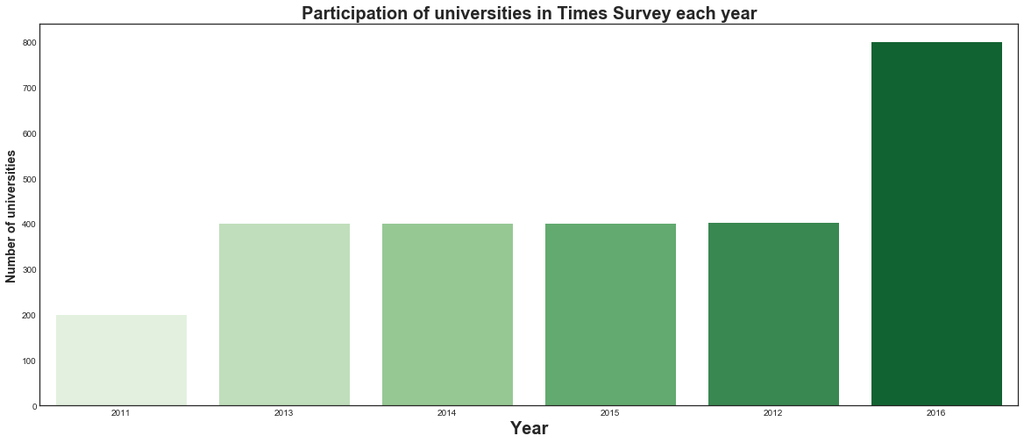

```python
# Using seaborn library of Python for visualizing by means of a countplot
plt.figure(figsize=(20,8))
sns.set_style("white")
sns.countplot(x="year",data=df,palette="Greens",order=df.year.value_counts().sort_values(ascending=True).index)
#sns.pointplot(data=df, x=participation_each_year.index, y=participation_each_year.values, color='dimgrey', marker='o')
plt.title('Participation of universities in Times Survey each year',fontsize=20,fontweight='bold')
plt.xlabel('Year',fontsize=20,fontweight='bold')
plt.ylabel('Number of universities',fontsize=14,fontweight='bold')
```

## Top 10 universities each year

```python
Top10Universities_EachYear=df[['year','university_name','world_rank']].groupby('year').head(10)
print(Top10Universities_EachYear.to_string(index=False))
```

```
year                                    university_name world_rank
2011                                 Harvard University          1
2011                 California Institute of Technology          2
2011              Massachusetts Institute of Technology          3
2011                                Stanford University          4
2011                               Princeton University          5
2011                            University of Cambridge          6
2011                               University of Oxford          6
2011                 University of California, Berkeley          8
2011                            Imperial College London          9
2011                                    Yale University         10
2012                 California Institute of Technology          1
2012                                 Harvard University          2
2012                                Stanford University          2
2012                               University of Oxford          4
```

[output cut: 54 more lines]

### Changes in Ranking of Top 10 universities across years

```python
Top10Universities_EachYear['world_rank'] = Top10Universities_EachYear['world_rank'].apply(pd.to_numeric)
```

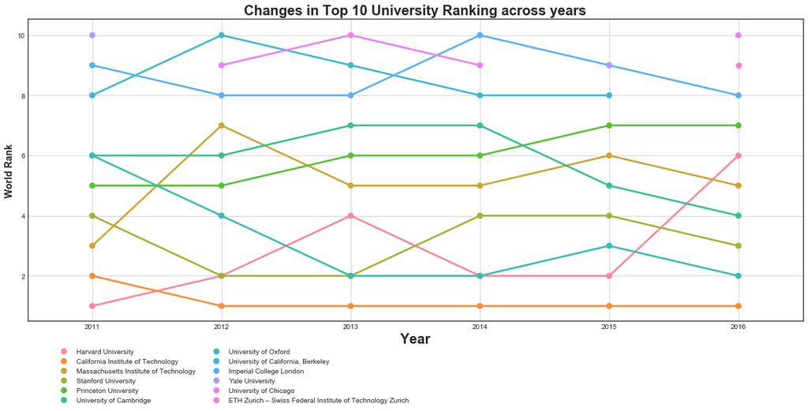

```python
# Using seaborn library of Python for visualizing by means of a pointplot
plt.figure(figsize=(20,8))
ax=sns.pointplot(data=Top10Universities_EachYear, x="year", y="world_rank",hue="university_name",marker='o')
ax.grid(True)
plt.title('Changes in Top 10 University Ranking across years',fontsize=20,fontweight='bold')
plt.xlabel('Year',fontsize=20,fontweight='bold')
plt.ylabel('World Rank',fontsize=14,fontweight='bold')
plt.legend(loc='upper right', bbox_to_anchor=(0.5, -0.07), ncol=2)
```

### World's Top 10 universities by number of students enrolled each year

```python
Top10Universities_StudentPop=df[['year','university_name','num_students']].groupby('year').head(10).sort_values(['year','num_students'],ascending=[True, False])
print(Top10Universities_StudentPop.to_string(index=False))
```

```
year                                    university_name  num_students
2011                 University of California, Berkeley       36186.0
2011                                 Harvard University       20152.0
2011                               University of Oxford       19919.0
2011                            University of Cambridge       18812.0
2011                                Stanford University       15596.0
2011                            Imperial College London       15060.0
2011                                    Yale University       11751.0
2011              Massachusetts Institute of Technology       11074.0
2011                               Princeton University        7929.0
2011                 California Institute of Technology        2243.0
2012                 University of California, Berkeley       36186.0
2012                                 Harvard University       20152.0
2012                               University of Oxford       19919.0
2012                            University of Cambridge       18812.0
```

[output cut: 46 more lines]

### Top 10 most populated universities in the world

```
Text(0,0.5,'Average number of students')
```

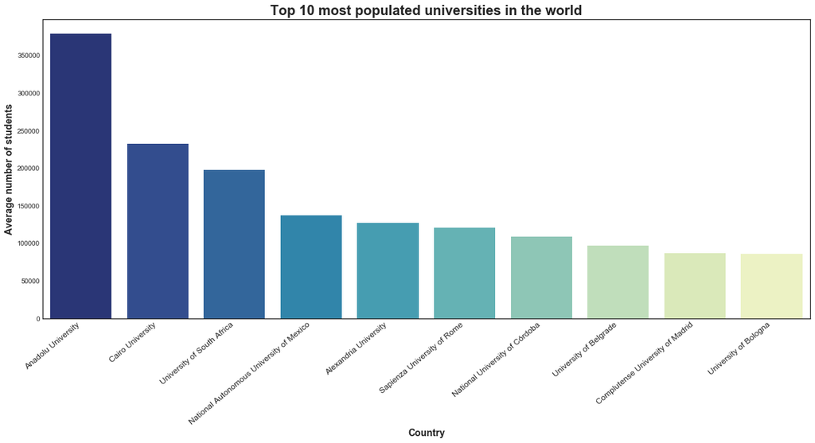

```python
# Using seaborn library of Python for visualizing by means of a barplot
Most_Populated_Universities=df[['university_name','num_students']].groupby('university_name')['num_students'].mean().nlargest(10)
plt.figure(figsize=(20,8))
ax=sns.barplot(x=Most_Populated_Universities.index,y=Most_Populated_Universities.values,palette="YlGnBu_r")
ax.set_xticklabels(ax.get_xticklabels(), rotation=40, ha="right",fontsize=12)
plt.title('Top 10 most populated universities in the world',fontsize=20,fontweight='bold')
plt.xlabel('Country',fontsize=14,fontweight='bold')
plt.ylabel('Average number of students',fontsize=14,fontweight='bold')
```

## Top 10 foreigner friendly universities

```python
#We will be plotting this by taking mean % for "international_students" across years for each university
Top10ForeignerFriendlyUniversities = df.groupby('university_name')['international_students'].mean().nlargest(10)
Top10ForeignerFriendlyUniversities
```

```
university_name
American University of Sharjah              82.0
Royal College of Surgeons in Ireland        63.0
École Polytechnique Fédérale de Lausanne    54.0
University of Luxembourg                    52.0
Imperial College London                     51.0
City University London                      50.0
Maastricht University                       48.0
University of St Andrews                    47.0
University College London                   46.0
Macquarie University                        44.0
Name: international_students, dtype: float64
```

```
Text(0,0.5,'Average % of international students')
```

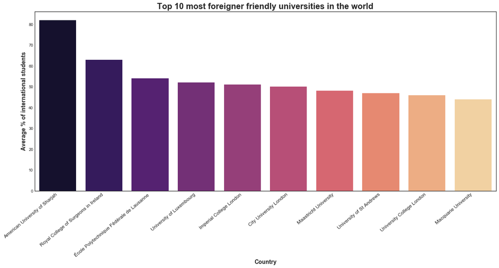

```python
# Using seaborn library of Python for visualizing by means of a barplot
plt.figure(figsize=(20,8))
ax=sns.barplot(x=Top10ForeignerFriendlyUniversities.index,y=Top10ForeignerFriendlyUniversities.values,palette="magma")
ax.set_xticklabels(ax.get_xticklabels(), rotation=40, ha="right",fontsize=12)
plt.title('Top 10 most foreigner friendly universities in the world',fontsize=20,fontweight='bold')
plt.xlabel('Country',fontsize=14,fontweight='bold')
plt.ylabel('Average % of international students',fontsize=14,fontweight='bold')
```

## Top 10 Universities good for research work

```python
#We will be plotting this by taking mean score for "research" across years for each university
Top10UniversitiesForResearch= df.groupby('university_name')['research'].mean().nlargest(10)
Top10UniversitiesForResearch
```

```
university_name
Harvard University                                           98.466667
California Institute of Technology                           98.250000
Stanford University                                          97.583333
University of Oxford                                         97.283333
University of California, Berkeley                           97.216667
Princeton University                                         96.350000
University of Cambridge                                      95.250000
University of California, Los Angeles                        91.550000
Yale University                                              90.416667
ETH Zurich – Swiss Federal Institute of Technology Zurich    89.950000
Name: research, dtype: float64
```

```
Text(0,0.5,'Average score for research')
```

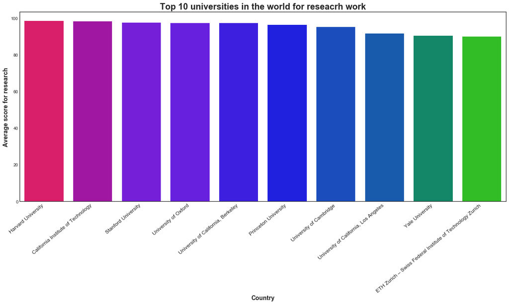

```python
# Using seaborn library of Python for visualizing by means of a barplot
plt.figure(figsize=(20,8))
ax=sns.barplot(x=Top10UniversitiesForResearch.index,y=Top10UniversitiesForResearch.values,palette="prism")
ax.set_xticklabels(ax.get_xticklabels(), rotation=40, ha="right",fontsize=12)
plt.title('Top 10 universities in the world for reseacrh work',fontsize=20,fontweight='bold')
plt.xlabel('Country',fontsize=14,fontweight='bold')
plt.ylabel('Average score for research',fontsize=14,fontweight='bold')
```

From above graph we have seen Top 10 universities acoss the world based on various parameters.Coming towards end of our Exploratory Data Analysis,we can find out Top 10 countries which stand good on these parameters.

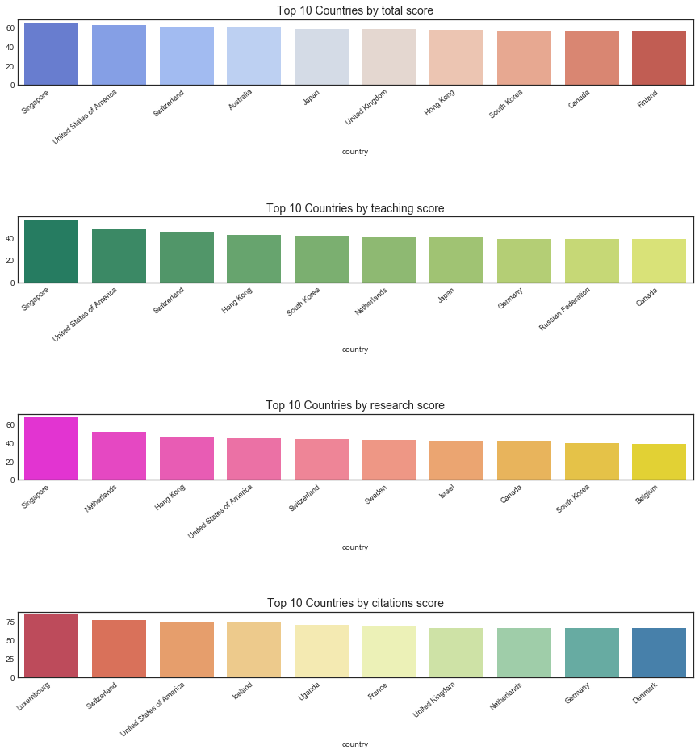

```python
#We will be creating sub-plots here
Top10CountriesOverall = df[df['total_score']!=0].groupby('country')['total_score'].mean().nlargest(10)
Top10CountriesForTeaching = df[df['teaching']!=0].groupby('country')['teaching'].mean().nlargest(10)
Top10CountriesForResearch = df[df['research']!=0].groupby('country')['research'].mean().nlargest(10)
Top10CountriesByCitation = df[df['citations']!=0].groupby('country')['citations'].mean().nlargest(10)

#df[df['total_score']!=0] has been used above to eliminate usgae of those records for which 0 is present from mean calculation

fig, axarr = plt.subplots(4, 1, figsize=(15,15))
sns.barplot(Top10CountriesOverall.index, Top10CountriesOverall.values,orient='v', ax=axarr[0],palette='coolwarm')
axarr[0].set_title("Top 10 Countries by total score", fontsize=14)
axarr[0].set_xticklabels(Top10CountriesOverall.index, rotation=40, ha="right",fontsize=9)
sns.barplot(Top10CountriesForTeaching.index, Top10CountriesForTeaching.values,orient='v', ax=axarr[1],palette='summer')
axarr[1].set_title("Top 10 Countries by teaching score", fontsize=14)
axarr[1].set_xticklabels(Top10CountriesForTeaching.index, rotation=40, ha="right",fontsize=9)
sns.barplot(Top10CountriesForResearch.index, Top10CountriesForResearch.values,orient='v', ax=axarr[2],palette='spring')
axarr[2].set_title("Top 10 Countries by research score", fontsize=14)
axarr[2].set_xticklabels(Top10CountriesForResearch.index, rotation=40, ha="right",fontsize=9)
sns.barplot(Top10CountriesByCitation.index, Top10CountriesByCitation.values,orient='v', ax=axarr[3],palette='Spectral')
axarr[3].set_title("Top 10 Countries by citations score", fontsize=14)
axarr[3].set_xticklabels(Top10CountriesByCitation.index, rotation=40, ha="right",fontsize=9)
plt.subplots_adjust(hspace=2)
```

```python
def answer_three():
    df = pd.read_csv("timesData.csv")
    df_subset=df[df['country'].isin(answer_two())].sort_values(['country', 'year'], ascending=[True, True])
    df_subset['international_students']=pd.to_numeric(df_subset['international_students'].map(str).apply(lambda x : x.strip('%')))
    x=df_subset.groupby('university_name')['international_students'].mean().nlargest(1)
    most_foreigner_friendly_universtity=x.index[0]
    return most_foreigner_friendly_universtity
answer_three()
```

```
'University of Luxembourg'
```

***Completion of Task3**